# Import and Export of India

Math2349 Assignment 3

Riya Minesh Amin s3807007

```r
# libraries
library(dplyr)
library(tidyr)
library(stringr)
library(knitr)
library(ggplot2)
library(lubridate)
library(kableExtra)
library(outliers)
library(readr)
library(plotly)
library(tidyverse)
library(DT)
```

## Executive Summary

India is one of the world’s fastest developing nations, and the main component of any developing nation is trade between nations. The datasets consists of the commodities traded in the HS2 basket (import export data EDA | Kaggle. 2019. import export data EDA | Kaggle.). The datasets were used from Kaggle. The dataset consists of exchange values in the sum of US$ million for exporting and importing goods.There are two datasets imported in this report. The necessary libraries were loaded followed by the two dataset Import and Export csvs’ of India. These dataset were than checked for any missing values, tidyness, outliers, classes of all the variables.

## Data

```r
# Data Import

Import <- read_csv("D:/2018-2010_import.csv")
Export <- read_csv("D:/2018-2010_export.csv")
```

## Understand

- This section shows the class of the variables of both the dataset, dimensions, names, sapply and head of the dataset.

```r
class(Import)
```

```
## [1] "spec_tbl_df" "tbl_df"      "tbl"         "data.frame"
```

```r
class(Export)
```

```
## [1] "spec_tbl_df" "tbl_df"      "tbl"         "data.frame"
```

```r
dim(Import)
```

```
## [1] 93095     5
```

```r
dim(Export)
```

```
## [1] 137023      5
```

```r
names(Import)
```

```
## [1] "HSCode"    "Commodity" "value"     "country"   "year"
```

```r
names(Export)
```

```
## [1] "HSCode"    "Commodity" "value"     "country"   "year"
```

```r
sapply(Import,class)
```

```
##      HSCode   Commodity       value     country        year
## "character" "character"   "numeric" "character"   "numeric"
```

```r
sapply(Export,class)
```

```
##      HSCode   Commodity       value     country        year
##   "numeric" "character"   "numeric" "character"   "numeric"
```

```r
head(Import)
```

| HSCode | Commodity | value | country | year |
| --- | --- | --- | --- | --- |
| 05 | PRODUCTS OF ANIMAL ORIGIN, NOT ELSEWHERE SPECIFIED OR INCLUDED. | 0.00 | AFGHANISTAN TIS | 2018 |
| 07 | EDIBLE VEGETABLES AND CERTAIN ROOTS AND TUBERS. | 12.38 | AFGHANISTAN TIS | 2018 |
| 08 | EDIBLE FRUIT AND NUTS; PEEL OR CITRUS FRUIT OR MELONS. | 268.60 | AFGHANISTAN TIS | 2018 |
| 09 | COFFEE, TEA, MATE AND SPICES. | 35.48 | AFGHANISTAN TIS | 2018 |
| 11 | PRODUCTS OF THE MILLING INDUSTRY; MALT; STARCHES; INULIN; WHEAT GLUTEN. | NA | AFGHANISTAN TIS | 2018 |
| 12 | OIL SEEDS AND OLEA. FRUITS; MISC. GRAINS, SEEDS AND FRUIT; INDUSTRIAL OR MEDICINAL PLANTS; STRAW AND FODDER. | 8.32 | AFGHANISTAN TIS | 2018 |

```r
head(Export)
```

| HSCode | Commodity | value | country | year |
| --- | --- | --- | --- | --- |
| 2 | MEAT AND EDIBLE MEAT OFFAL. | 0.18 | AFGHANISTAN TIS | 2018 |
| 3 | FISH AND CRUSTACEANS, MOLLUSCS AND OTHER AQUATIC INVERTABRATES. | 0.00 | AFGHANISTAN TIS | 2018 |
| 4 | DAIRY PRODUCE; BIRDS' EGGS; NATURAL HONEY; EDIBLE PROD. OF ANIMAL ORIGIN, NOT ELSEWHERE SPEC. OR INCLUDED. | 12.48 | AFGHANISTAN TIS | 2018 |
| 6 | LIVE TREES AND OTHER PLANTS; BULBS; ROOTS AND THE LIKE; CUT FLOWERS AND ORNAMENTAL FOLIAGE. | 0.00 | AFGHANISTAN TIS | 2018 |
| 7 | EDIBLE VEGETABLES AND CERTAIN ROOTS AND TUBERS. | 1.89 | AFGHANISTAN TIS | 2018 |
| 8 | EDIBLE FRUIT AND NUTS; PEEL OR CITRUS FRUIT OR MELONS. | 25.01 | AFGHANISTAN TIS | 2018 |

## Changing the class

### Here HSCode should be a Factor instead of Character.

```r
Import$HSCode <- factor(Import$HSCode)
Export$HSCode <- factor(Export$HSCode)
```

- Above we can see that the dataset is tidy and each row consists of a single observation.

# Mutating column HSCODE AND COMMODITY

```r
#utility function used from stackoverflow
HSC1 <- function(cm,h){
  #cm <- gsub(pattern = ',',replacement = ';',x = cm)
  com <-substr(cm,start = 1,stop = 15)
  # com <- com[1]
  HSCode <- paste("HSCode",as.character(h),sep=': ')
  paste(com,HSCode,sep=' - ')
}

HSC2 <- function(cmv,hv){
  rtv <- character()
  for(i in 1:length(cmv)){
    rtv[i] <- HSC1(cmv[i],hv[i])
  }
  rtv
}
```

```r
HSC_Commodity <- Import[,c(1,2)] %>% distinct()
HSC_Commodity <- HSC_Commodity %>% mutate(Commodity_HSCode = HSC2(Commodity,HSCode))
```

# Scaning MISSING VALUES

```r
colSums(is.na.data.frame(Import))
```

```
##    HSCode Commodity     value   country      year
##         0         0     14027         0         0
```

```r
colSums(is.na.data.frame(Export))
```

```
##    HSCode Commodity     value   country      year
##         0         0     14038         0         0
```

## Subsetting the blank columns

To remove the missing values the blank columns are filtered.

```r
Import_na <- Import %>% filter(is.na(value))
Export_na <- Export %>% filter(is.na(value))

Import <- Import %>% filter(!is.na(value))
Export <- Export %>% filter(!is.na(value))
```

### checking again the missing values

```r
colSums(is.na.data.frame(Import))
```

```
##    HSCode Commodity     value   country      year
##         0         0         0         0         0
```

```r
colSums(is.na.data.frame(Export))
```

```
##    HSCode Commodity     value   country      year
##         0         0         0         0         0
```

# Analysing the data

### Now to summarise the Import and Export per year a new data frame is formed for Import and Export each and mutated together to compare the same.

```r
summary_Import <- Import %>% group_by(year) %>% summarise(import = sum(value))
summary_Export <- Export %>% group_by(year) %>% summarise(export = sum(value))
summary_Import_Export <- merge(summary_Import,summary_Export,x.by = year, y.by = year) %>% gather('Type','Value',-year)

summary_Import_Export <- summary_Import_Export %>% mutate(V_in_billion = Value/1000)
summary_Import_Export
```

| year | Type | Value | V_in_billion |
| --- | --- | --- | --- |
| 2010 | import | 369762.2 | 369.7622 |
| 2011 | import | 489311.8 | 489.3118 |
| 2012 | import | 490730.1 | 490.7301 |
| 2013 | import | 450193.0 | 450.1930 |
| 2014 | import | 448026.6 | 448.0266 |
| 2015 | import | 412537.5 | 412.5375 |
| 2016 | import | 384350.3 | 384.3503 |
| 2017 | import | 931148.0 | 931.1480 |
| 2018 | import | 1028142.7 | 1028.1427 |
| 2010 | export | 249801.2 | 249.8012 |

[output cut: 8 more lines]

To summarise the above new dataframe, below the plot demonstates the over all imports and exports of India over years 2010 to 2018

```r
Import_Export_G <- ggplot(summary_Import_Export)+
  geom_segment(aes(x = 2017, y = 384350.35/1000, xend= 2017,yend = 931148.0/1000), arrow = arrow(length = unit(0.1, "inches")))+
  geom_segment(aes(x = 2016, y = 384350.3/1000, xend= 2017,yend = 384350.35/1000), linetype =1)+
    geom_point(aes(x=year,y=V_in_billion,color=Type),size = 2, alpha = 0.6)+
    geom_line(aes(x=year,y=V_in_billion,color=Type))+
  annotate('text',x = 2016,y = 650,
                label = "From 2016 to 2017\nimport increased by\n546.797 billion")+
  labs(x = "years", y="Import_Export in billions")+
  theme(legend.title = element_blank(),
        panel.border = element_rect(colour = "dark green", fill=NA, size=0.5))


ggplotly(Import_Export_G) %>% layout(legend = list(x = 0, y = 1,
                                      bordercolor="white",
                                      borderwidth=0.5))
```

[interactive chart not shown]

## Analysing cont..

```r
Top_Import <- Import %>% group_by(HSCode) %>% summarise(value = sum(value)) %>% top_n( 3,value)
#Top_Import <- merge(Top_Import,HSC_Commodity,by='HSCode')
Top_Import1 <- Import %>% filter(HSCode %in% Top_Import$HSCode) %>%
  group_by(year,HSCode) %>%
  summarise(v_in_billion = sum(value)/1000)

Top_Import1 <- merge(Top_Import1,HSC_Commodity,by='HSCode')


ImportG2 <- ggplot(Top_Import1)+
  geom_point(aes(x=year,y=v_in_billion,color=Commodity_HSCode),size = 0.5, alpha = 0.9)+
  geom_line(aes(x=year,y=v_in_billion,color=Commodity_HSCode))+
  labs(x = "", y="Imports in billions")+
  theme(panel.border = element_rect(colour = "black", fill=NA, size=2))
ggplotly(ImportG2) %>% hide_legend()
```

[interactive chart not shown]

```r
Top_Export <- Export %>% group_by(HSCode) %>% summarise(value = sum(value)) %>% top_n( 3,value)
Top_Export2 <- Export %>% filter(HSCode %in% Top_Import$HSCode) %>%
  group_by(year,HSCode) %>%
  summarise(v_in_billion = sum(value)/1000)
Top_Export2 <- merge(Top_Export2,HSC_Commodity,by='HSCode')

ExportG2 <- ggplot(Top_Export2)+
  geom_point(aes(x=year,y=v_in_billion,color=Commodity_HSCode),size = 0.5, alpha = 0.9)+
  geom_line(aes(x=year,y=v_in_billion,color=Commodity_HSCode))+
  labs(x = "", y="Exports in billions")+
  theme(panel.border = element_rect(colour = "black", fill=NA, size=2))

ggplotly(ExportG2) %>% hide_legend()
```

[interactive chart not shown]

## Outliers Detection

Below outliers have been detected in the import and export Values

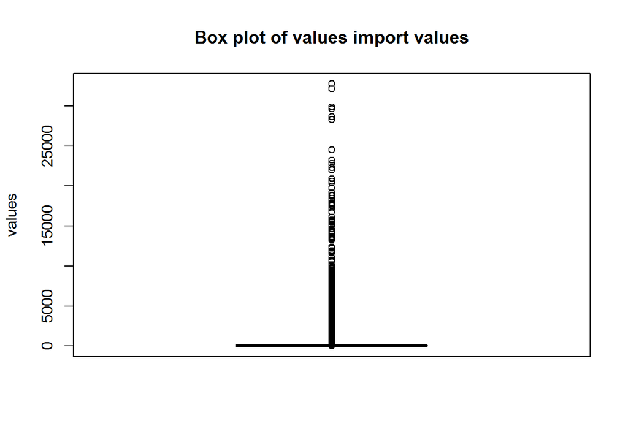

```r
Import$value %>% boxplot(main="Box plot of values import values", ylab="values", col= "grey")
```

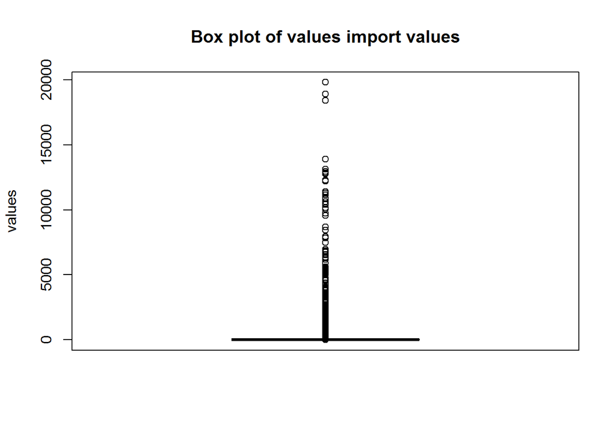

```r
Export$value %>% boxplot(main="Box plot of values import values", ylab="values", col= "grey")
```

## To replace the outliers, Capping/Winsorising is used.

Capping or winsorizing involves replacing the outliers that are not outliers with the nearest neighbors.

```r
# Capping is use to replace the outliers.
#function to define cap below is used from module notes and stackoverflow

cap <- function(x){
    quantiles <- quantile( x, c(.05, 0.25, 0.75, .95 ) )
    x[ x < quantiles[2] - 1.5*IQR(x) ] <- quantiles[1]
    x[ x > quantiles[3] + 1.5*IQR(x) ] <- quantiles[4]
    x
}
Import_values_capped <- Import$value %>% cap()
Export_values_capped <- Export$value %>% cap()


#subset using value
import_value_sub <- Import %>% dplyr::select(value)
export_value_sub <- Export %>% dplyr::select(value)

#descriptive statistics
summary(import_value_sub)
```

```
##      value
##  Min.   :    0.00
##  1st Qu.:    0.03
##  Median :    0.38
##  Mean   :   63.29
##  3rd Qu.:    4.91
##  Max.   :32781.57
```

```r
summary(export_value_sub)
```

```
##      value
##  Min.   :    0.00
##  1st Qu.:    0.03
##  Median :    0.36
##  Mean   :   21.57
##  3rd Qu.:    3.77
##  Max.   :19805.17
```

```r
#apply user defined function "cap" to value_sub
Import_values_capped <- sapply(import_value_sub, FUN = cap)
Export_values_capped <- sapply(export_value_sub, FUN = cap)

#check statistics
summary(Import_values_capped)
```

```
##      value
##  Min.   :  0.00
##  1st Qu.:  0.03
##  Median :  0.38
##  Mean   : 24.19
##  3rd Qu.:  4.91
##  Max.   :131.51
```

```r
summary(Export_values_capped)
```

```
##      value
##  Min.   : 0.00
##  1st Qu.: 0.03
##  Median : 0.36
##  Mean   :10.94
##  3rd Qu.: 3.77
##  Max.   :60.83
```

## Transforming

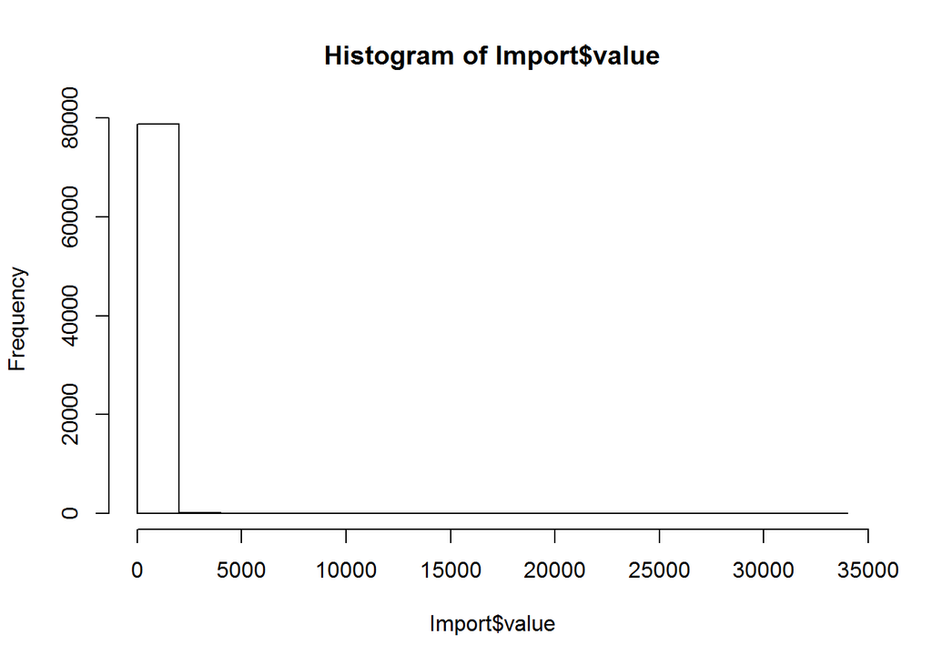

```r
#The Log Tranformation
#Hypothetical data on the Import data

hist(Import$value)
```

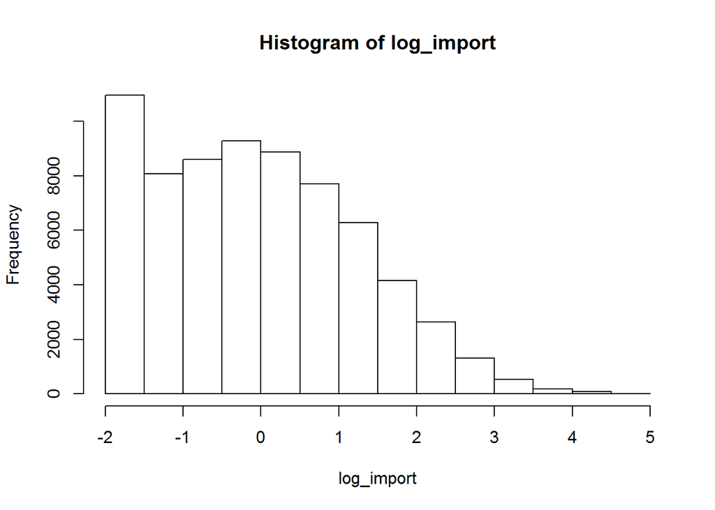

```r
#we apply the log10() transformation

log_import <- log10(Import$value)
hist(log_import)
```

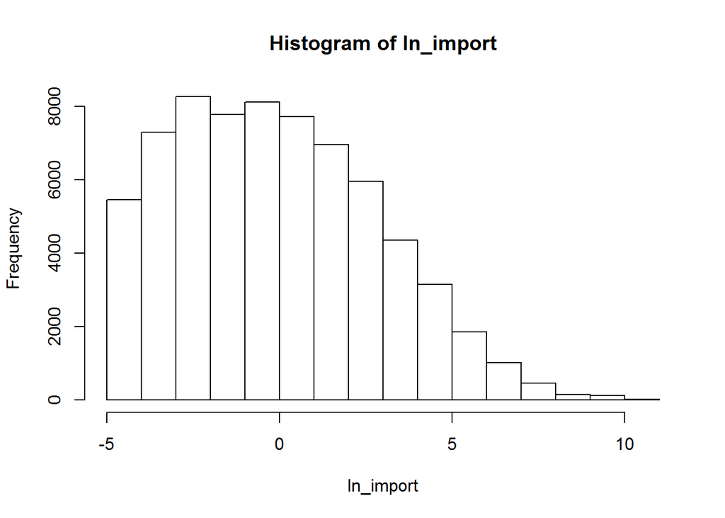

```r
#lets check ln transformation
ln_import <- log(Import$value)
hist(ln_import)
```

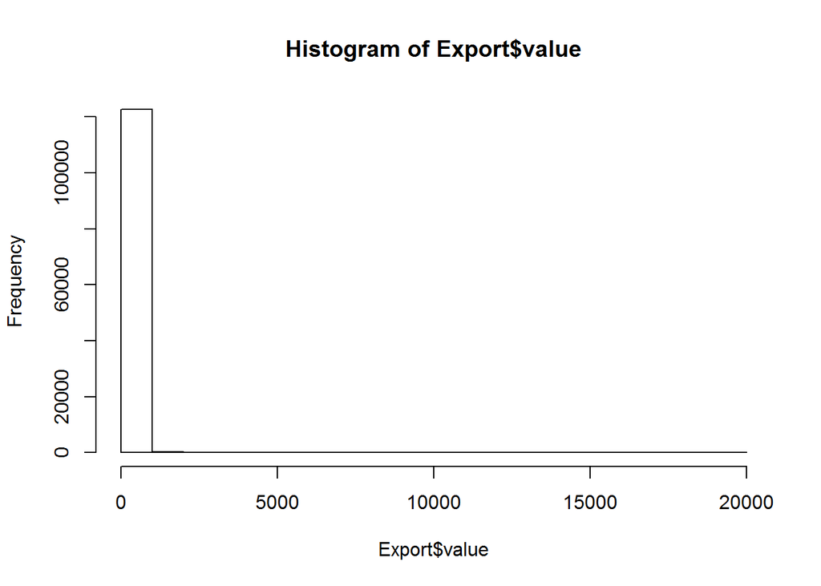

```r
#The Log Tranformation
#Hypothetical data on the Export data

hist(Export$value)
```

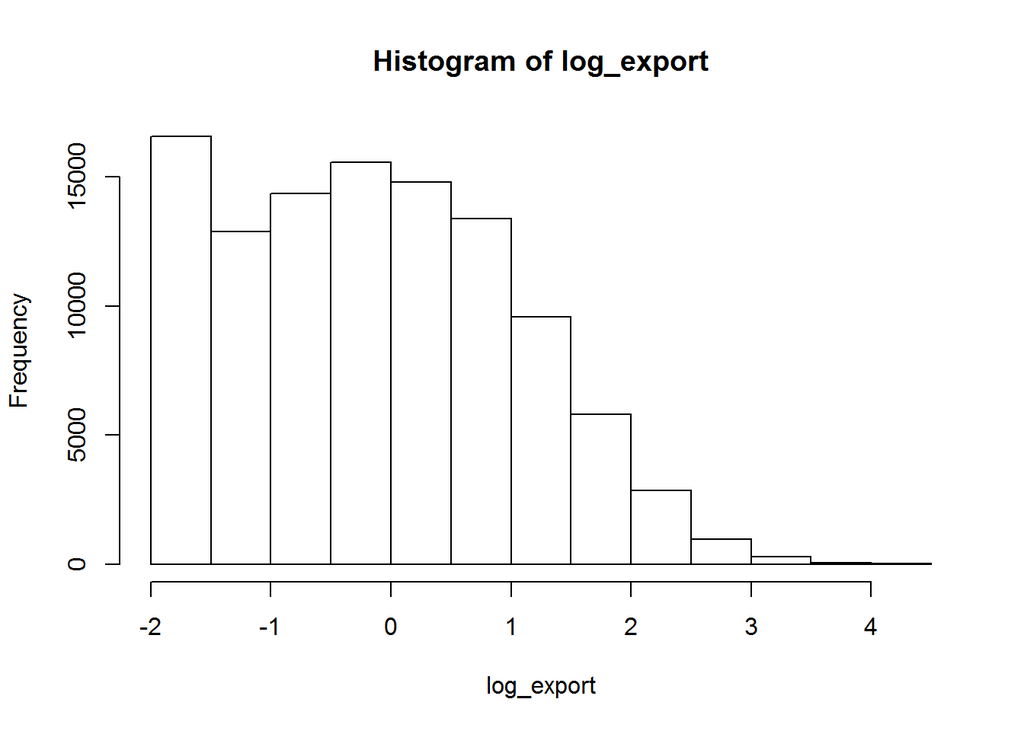

```r
#we apply the log10() transformation

log_export <- log10(Export$value)
hist(log_export)
```

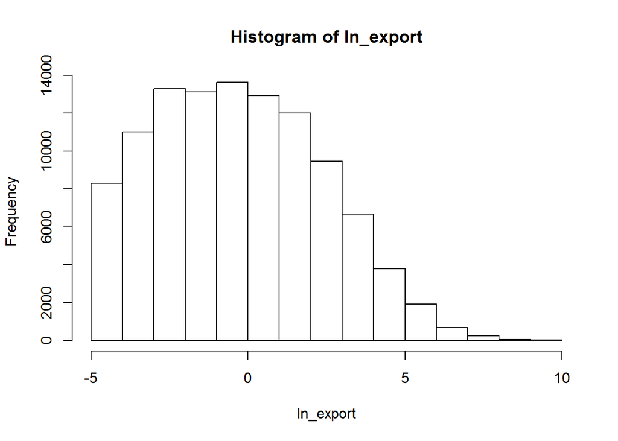

```r
#lets check ln transformation
ln_export <- log(Export$value)
hist(ln_export)
```